# Wrangle_Act

|  | contributors | coordinates | created_at | display_text_range | entities | extended_entities | favorite_count | favorited | full_text | geo | ... | possibly_sensitive_appealable | quoted_status | quoted_status_id | quoted_status_id_str | retweet_count | retweeted | retweeted_status | source | truncated | user |
| --- | --- | --- | --- | --- | --- | --- | --- | --- | --- | --- | --- | --- | --- | --- | --- | --- | --- | --- | --- | --- | --- |
| 0 | NaN | NaN | 2017-08-01 16:23:56 | [0, 85] | {'hashtags': [], 'symbols': [], 'user_mentions... | {'media': [{'id': 892420639486877696, 'id_str'... | 39467 | False | This is Phineas. He's a mystical boy. Only eve... | NaN | ... | 0.0 | NaN | NaN | NaN | 8853 | False | NaN | <a href="http://twitter.com/download/iphone" r... | False | {'id': 4196983835, 'id_str': '4196983835', 'na... |
| 1 | NaN | NaN | 2017-08-01 00:17:27 | [0, 138] | {'hashtags': [], 'symbols': [], 'user_mentions... | {'media': [{'id': 892177413194625024, 'id_str'... | 33819 | False | This is Tilly. She's just checking pup on you.... | NaN | ... | 0.0 | NaN | NaN | NaN | 6514 | False | NaN | <a href="http://twitter.com/download/iphone" r... | False | {'id': 4196983835, 'id_str': '4196983835', 'na... |
| 2 | NaN | NaN | 2017-07-31 00:18:03 | [0, 121] | {'hashtags': [], 'symbols': [], 'user_mentions... | {'media': [{'id': 891815175371796480, 'id_str'... | 25461 | False | This is Archie. He is a rare Norwegian Pouncin... | NaN | ... | 0.0 | NaN | NaN | NaN | 4328 | False | NaN | <a href="http://twitter.com/download/iphone" r... | False | {'id': 4196983835, 'id_str': '4196983835', 'na... |
| 3 | NaN | NaN | 2017-07-30 15:58:51 | [0, 79] | {'hashtags': [], 'symbols': [], 'user_mentions... | {'media': [{'id': 891689552724799489, 'id_str'... | 42908 | False | This is Darla. She commenced a snooze mid meal... | NaN | ... | 0.0 | NaN | NaN | NaN | 8964 | False | NaN | <a href="http://twitter.com/download/iphone" r... | False | {'id': 4196983835, 'id_str': '4196983835', 'na... |
| 4 | NaN | NaN | 2017-07-29 16:00:24 | [0, 138] | {'hashtags': [{'text': 'BarkWeek', 'indices': ... | {'media': [{'id': 891327551943041024, 'id_str'... | 41048 | False | This is Franklin. He would like you to stop ca... | NaN | ... | 0.0 | NaN | NaN | NaN | 9774 | False | NaN | <a href="http://twitter.com/download/iphone" r... | False | {'id': 4196983835, 'id_str': '4196983835', 'na... |
| 5 | NaN | NaN | 2017-07-29 00:08:17 | [0, 138] | {'hashtags': [{'text': 'BarkWeek', 'indices': ... | {'media': [{'id': 891087942176911360, 'id_str'... | 20562 | False | Here we have a majestic great white breaching ... | NaN | ... | 0.0 | NaN | NaN | NaN | 3261 | False | NaN | <a href="http://twitter.com/download/iphone" r... | False | {'id': 4196983835, 'id_str': '4196983835', 'na... |
| 6 | NaN | NaN | 2017-07-28 16:27:12 | [0, 140] | {'hashtags': [], 'symbols': [], 'user_mentions... | {'media': [{'id': 890971906207338496, 'id_str'... | 12041 | False | Meet Jax. He enjoys ice cream so much he gets ... | NaN | ... | 0.0 | NaN | NaN | NaN | 2158 | False | NaN | <a href="http://twitter.com/download/iphone" r... | False | {'id': 4196983835, 'id_str': '4196983835', 'na... |
| 7 | NaN | NaN | 2017-07-28 00:22:40 | [0, 118] | {'hashtags': [], 'symbols': [], 'user_mentions... | {'media': [{'id': 890729118844600320, 'id_str'... | 56848 | False | When you watch your owner call another dog a g... | NaN | ... | 0.0 | NaN | NaN | NaN | 16716 | False | NaN | <a href="http://twitter.com/download/iphone" r... | False | {'id': 4196983835, 'id_str': '4196983835', 'na... |
| 8 | NaN | NaN | 2017-07-27 16:25:51 | [0, 122] | {'hashtags': [{'text': 'BarkWeek', 'indices': ... | {'media': [{'id': 890609177319665665, 'id_str'... | 28226 | False | This is Zoey. She doesn't want to be one of th... | NaN | ... | 0.0 | NaN | NaN | NaN | 4429 | False | NaN | <a href="http://twitter.com/download/iphone" r... | False | {'id': 4196983835, 'id_str': '4196983835', 'na... |
| 9 | NaN | NaN | 2017-07-26 15:59:51 | [0, 133] | {'hashtags': [], 'symbols': [], 'user_mentions... | {'media': [{'id': 890240245463175168, 'id_str'... | 32467 | False | This is Cassie. She is a college pup. Studying... | NaN | ... | 0.0 | NaN | NaN | NaN | 7711 | False | NaN | <a href="http://twitter.com/download/iphone" r... | False | {'id': 4196983835, 'id_str': '4196983835', 'na... |
| 10 | NaN | NaN | 2017-07-26 00:31:25 | [0, 130] | {'hashtags': [{'text': 'BarkWeek', 'indices': ... | {'media': [{'id': 890006600089468928, 'id_str'... | 31166 | False | This is Koda. He is a South Australian decksha... | NaN | ... | 0.0 | NaN | NaN | NaN | 7624 | False | NaN | <a href="http://twitter.com/download/iphone" r... | False | {'id': 4196983835, 'id_str': '4196983835', 'na... |
| 11 | NaN | NaN | 2017-07-25 16:11:53 | [0, 107] | {'hashtags': [], 'symbols': [], 'user_mentions... | {'media': [{'id': 889880888800096258, 'id_str'... | 28268 | False | This is Bruno. He is a service shark. Only get... | NaN | ... | 0.0 | NaN | NaN | NaN | 5156 | False | NaN | <a href="http://twitter.com/download/iphone" r... | False | {'id': 4196983835, 'id_str': '4196983835', 'na... |
| 12 | NaN | NaN | 2017-07-25 01:55:32 | [0, 106] | {'hashtags': [], 'symbols': [], 'user_mentions... | {'media': [{'id': 889665366129029120, 'id_str'... | 38818 | False | Here's a puppo that seems to be on the fence a... | NaN | ... | 0.0 | NaN | NaN | NaN | 8538 | False | NaN | <a href="http://twitter.com/download/iphone" r... | False | {'id': 4196983835, 'id_str': '4196983835', 'na... |
| 13 | NaN | NaN | 2017-07-25 00:10:02 | [0, 91] | {'hashtags': [], 'symbols': [], 'user_mentions... | {'media': [{'id': 889638825424826374, 'id_str'... | 27672 | False | This is Ted. He does his best. Sometimes that'... | NaN | ... | 0.0 | NaN | NaN | NaN | 4735 | False | NaN | <a href="http://twitter.com/download/iphone" r... | False | {'id': 4196983835, 'id_str': '4196983835', 'na... |
| 14 | NaN | NaN | 2017-07-24 17:02:04 | [0, 118] | {'hashtags': [{'text': 'BarkWeek', 'indices': ... | {'media': [{'id': 889531127467266049, 'id_str'... | 15359 | False | This is Stuart. He's sporting his favorite fan... | NaN | ... | 0.0 | NaN | NaN | NaN | 2321 | False | NaN | <a href="http://twitter.com/download/iphone" r... | False | {'id': 4196983835, 'id_str': '4196983835', 'na... |
| 15 | NaN | NaN | 2017-07-24 00:19:32 | [0, 138] | {'hashtags': [{'text': 'BarkWeek', 'indices': ... | {'media': [{'id': 889278779352338437, 'id_str'... | 25652 | False | This is Oliver. You're witnessing one of his m... | NaN | ... | 0.0 | NaN | NaN | NaN | 5637 | False | NaN | <a href="http://twitter.com/download/iphone" r... | False | {'id': 4196983835, 'id_str': '4196983835', 'na... |
| 16 | NaN | NaN | 2017-07-23 00:22:39 | [0, 86] | {'hashtags': [], 'symbols': [], 'user_mentions... | {'media': [{'id': 888917229776945152, 'id_str'... | 29611 | False | This is Jim. He found a fren. Taught him how t... | NaN | ... | 0.0 | NaN | NaN | NaN | 4709 | False | NaN | <a href="http://twitter.com/download/iphone" r... | False | {'id': 4196983835, 'id_str': '4196983835', 'na... |
| 17 | NaN | NaN | 2017-07-22 16:56:37 | [0, 128] | {'hashtags': [], 'symbols': [], 'user_mentions... | {'media': [{'id': 888804981515575296, 'id_str'... | 26080 | False | This is Zeke. He has a new stick. Very proud o... | NaN | ... | 0.0 | NaN | NaN | NaN | 4559 | False | NaN | <a href="http://twitter.com/download/iphone" r... | False | {'id': 4196983835, 'id_str': '4196983835', 'na... |
| 18 | NaN | NaN | 2017-07-22 00:23:06 | [0, 87] | {'hashtags': [], 'symbols': [], 'user_mentions... | {'media': [{'id': 888554915546542081, 'id_str'... | 20290 | False | This is Ralphus. He's powering up. Attempting ... | NaN | ... | 0.0 | NaN | NaN | NaN | 3732 | False | NaN | <a href="http://twitter.com/download/iphone" r... | False | {'id': 4196983835, 'id_str': '4196983835', 'na... |
| 19 | NaN | NaN | 2017-07-20 16:49:33 | [0, 127] | {'hashtags': [], 'symbols': [], 'user_mentions... | {'media': [{'id': 888078426338406400, 'id_str'... | 22201 | False | This is Gerald. He was just told he didn't get... | NaN | ... | 0.0 | NaN | NaN | NaN | 3653 | False | NaN | <a href="http://twitter.com/download/iphone" r... | False | {'id': 4196983835, 'id_str': '4196983835', 'na... |
| 20 | NaN | NaN | 2017-07-19 16:06:48 | [0, 127] | {'hashtags': [], 'symbols': [], 'user_mentions... | {'media': [{'id': 887705281597243393, 'id_str'... | 30779 | False | This is Jeffrey. He has a monopoly on the pool... | NaN | ... | 0.0 | NaN | NaN | NaN | 5609 | False | NaN | <a href="http://twitter.com/download/iphone" r... | False | {'id': 4196983835, 'id_str': '4196983835', 'na... |
| 21 | NaN | NaN | 2017-07-19 03:39:09 | [0, 108] | {'hashtags': [], 'symbols': [], 'user_mentions... | {'media': [{'id': 887517108413886465, 'id_str'... | 46959 | True | I've yet to rate a Venezuelan Hover Wiener. Th... | NaN | ... | 0.0 | NaN | NaN | NaN | 12082 | False | NaN | <a href="http://twitter.com/download/iphone" r... | False | {'id': 4196983835, 'id_str': '4196983835', 'na... |
| 22 | NaN | NaN | 2017-07-19 00:47:34 | [0, 99] | {'hashtags': [], 'symbols': [], 'user_mentions... | {'media': [{'id': 887473949361045505, 'id_str'... | 69871 | False | This is Canela. She attempted some fancy porch... | NaN | ... | 0.0 | NaN | NaN | NaN | 18781 | False | NaN | <a href="http://twitter.com/download/iphone" r... | False | {'id': 4196983835, 'id_str': '4196983835', 'na... |
| 23 | NaN | NaN | 2017-07-18 16:08:03 | [0, 88] | {'hashtags': [], 'symbols': [], 'user_mentions... | {'media': [{'id': 887343120832229379, 'id_str'... | 34222 | False | You may not have known you needed to see this ... | NaN | ... | 0.0 | NaN | NaN | NaN | 10737 | False | NaN | <a href="http://twitter.com/download/iphone" r... | False | {'id': 4196983835, 'id_str': '4196983835', 'na... |
| 24 | NaN | NaN | 2017-07-18 00:07:08 | [0, 129] | {'hashtags': [], 'symbols': [], 'user_mentions... | {'media': [{'id': 887101385971384320, 'id_str'... | 31061 | False | This... is a Jubilant Antarctic House Bear. We... | NaN | ... | 0.0 | NaN | NaN | NaN | 6167 | False | NaN | <a href="http://twitter.com/download/iphone" r... | False | {'id': 4196983835, 'id_str': '4196983835', 'na... |
| 25 | NaN | NaN | 2017-07-17 16:17:36 | [0, 101] | {'hashtags': [], 'symbols': [], 'user_mentions... | {'media': [{'id': 886983218871902208, 'id_str'... | 35859 | False | This is Maya. She's very shy. Rarely leaves he... | NaN | ... | 0.0 | NaN | NaN | NaN | 8084 | False | NaN | <a href="http://twitter.com/download/iphone" r... | False | {'id': 4196983835, 'id_str': '4196983835', 'na... |
| 26 | NaN | NaN | 2017-07-16 23:58:41 | [0, 121] | {'hashtags': [], 'symbols': [], 'user_mentions... | {'media': [{'id': 886736868116754432, 'id_str'... | 12306 | False | This is Mingus. He's a wonderful father to his... | NaN | ... | 0.0 | NaN | NaN | NaN | 3443 | False | NaN | <a href="http://twitter.com/download/iphone" r... | False | {'id': 4196983835, 'id_str': '4196983835', 'na... |
| 27 | NaN | NaN | 2017-07-16 20:14:00 | [0, 71] | {'hashtags': [], 'symbols': [], 'user_mentions... | {'media': [{'id': 886680331239161856, 'id_str'... | 22798 | False | This is Derek. He's late for a dog meeting. 13... | NaN | ... | 0.0 | NaN | NaN | NaN | 4610 | False | NaN | <a href="http://twitter.com/download/iphone" r... | False | {'id': 4196983835, 'id_str': '4196983835', 'na... |
| 28 | NaN | NaN | 2017-07-15 23:25:31 | [0, 131] | {'hashtags': [], 'symbols': [], 'user_mentions... | {'media': [{'id': 886366138128449536, 'id_str'... | 21524 | False | This is Roscoe. Another pupper fallen victim t... | NaN | ... | 0.0 | NaN | NaN | NaN | 3316 | False | NaN | <a href="http://twitter.com/download/iphone" r... | False | {'id': 4196983835, 'id_str': '4196983835', 'na... |
| 29 | NaN | NaN | 2017-07-15 16:51:35 | [27, 105] | {'hashtags': [], 'symbols': [], 'user_mentions... | NaN | 117 | False | @NonWhiteHat @MayhewMayhem omg hello tanner yo... | NaN | ... | NaN | NaN | NaN | NaN | 4 | False | NaN | <a href="http://twitter.com/download/iphone" r... | False | {'id': 4196983835, 'id_str': '4196983835', 'na... |
| ... | ... | ... | ... | ... | ... | ... | ... | ... | ... | ... | ... | ... | ... | ... | ... | ... | ... | ... | ... | ... | ... |
| 2324 | NaN | NaN | 2015-11-17 00:24:19 | [0, 140] | {'hashtags': [], 'symbols': [], 'user_mentions... | {'media': [{'id': 666411498068123649, 'id_str'... | 459 | False | This is quite the dog. Gets really excited whe... | NaN | ... | 0.0 | NaN | NaN | NaN | 339 | False | NaN | <a href="http://twitter.com/download/iphone" r... | False | {'id': 4196983835, 'id_str': '4196983835', 'na... |
| 2325 | NaN | NaN | 2015-11-17 00:06:54 | [0, 139] | {'hashtags': [], 'symbols': [], 'user_mentions... | {'media': [{'id': 666407121513275392, 'id_str'... | 113 | False | This is a southern Vesuvius bumblegruff. Can d... | NaN | ... | 0.0 | NaN | NaN | NaN | 44 | False | NaN | <a href="http://twitter.com/download/iphone" r... | False | {'id': 4196983835, 'id_str': '4196983835', 'na... |
| 2326 | NaN | NaN | 2015-11-16 23:23:41 | [0, 137] | {'hashtags': [], 'symbols': [], 'user_mentions... | {'media': [{'id': 666396240351993856, 'id_str'... | 172 | False | Oh goodness. A super rare northeast Qdoba kang... | NaN | ... | 0.0 | NaN | NaN | NaN | 92 | False | NaN | <a href="http://twitter.com/download/iphone" r... | False | {'id': 4196983835, 'id_str': '4196983835', 'na... |
| 2327 | NaN | NaN | 2015-11-16 21:54:18 | [0, 81] | {'hashtags': [], 'symbols': [], 'user_mentions... | {'media': [{'id': 666373746337402880, 'id_str'... | 194 | False | Those are sunglasses and a jean jacket. 11/10 ... | NaN | ... | 0.0 | NaN | NaN | NaN | 100 | False | NaN | <a href="http://twitter.com/download/iphone" r... | False | {'id': 4196983835, 'id_str': '4196983835', 'na... |
| 2328 | NaN | NaN | 2015-11-16 21:10:36 | [0, 140] | {'hashtags': [], 'symbols': [], 'user_mentions... | {'media': [{'id': 666362717482020864, 'id_str'... | 804 | False | Unique dog here. Very small. Lives in containe... | NaN | ... | 0.0 | NaN | NaN | NaN | 595 | False | NaN | <a href="http://twitter.com/download/iphone" r... | False | {'id': 4196983835, 'id_str': '4196983835', 'na... |
| 2329 | NaN | NaN | 2015-11-16 20:32:58 | [0, 135] | {'hashtags': [], 'symbols': [], 'user_mentions... | {'media': [{'id': 666353280906170368, 'id_str'... | 229 | False | Here we have a mixed Asiago from the Galápagos... | NaN | ... | 0.0 | NaN | NaN | NaN | 77 | False | NaN | <a href="http://twitter.com/download/iphone" r... | False | {'id': 4196983835, 'id_str': '4196983835', 'na... |
| 2330 | NaN | NaN | 2015-11-16 20:01:42 | [0, 112] | {'hashtags': [], 'symbols': [], 'user_mentions... | {'media': [{'id': 666345414279471104, 'id_str'... | 307 | False | Look at this jokester thinking seat belt laws ... | NaN | ... | 0.0 | NaN | NaN | NaN | 146 | False | NaN | <a href="http://twitter.com/download/iphone" r... | False | {'id': 4196983835, 'id_str': '4196983835', 'na... |
| 2331 | NaN | NaN | 2015-11-16 19:31:45 | [0, 139] | {'hashtags': [], 'symbols': [], 'user_mentions... | {'media': [{'id': 666337857791987715, 'id_str'... | 204 | False | This is an extremely rare horned Parthenon. No... | NaN | ... | 0.0 | NaN | NaN | NaN | 96 | False | NaN | <a href="http://twitter.com/download/iphone" r... | False | {'id': 4196983835, 'id_str': '4196983835', 'na... |
| 2332 | NaN | NaN | 2015-11-16 16:37:02 | [0, 138] | {'hashtags': [], 'symbols': [], 'user_mentions... | {'media': [{'id': 666293909010702337, 'id_str'... | 522 | False | This is a funny dog. Weird toes. Won't come do... | NaN | ... | 0.0 | NaN | NaN | NaN | 368 | False | NaN | <a href="http://twitter.com/download/iphone" r... | False | {'id': 4196983835, 'id_str': '4196983835', 'na... |
| 2333 | NaN | NaN | 2015-11-16 16:11:11 | [0, 136] | {'hashtags': [], 'symbols': [], 'user_mentions... | {'media': [{'id': 666287399580733440, 'id_str'... | 152 | False | This is an Albanian 3 1/2 legged Episcopalian... | NaN | ... | 0.0 | NaN | NaN | NaN | 71 | False | NaN | <a href="http://twitter.com/download/iphone" r... | False | {'id': 4196983835, 'id_str': '4196983835', 'na... |
| 2334 | NaN | NaN | 2015-11-16 15:14:19 | [0, 46] | {'hashtags': [], 'symbols': [], 'user_mentions... | {'media': [{'id': 666273081518768128, 'id_str'... | 184 | False | Can take selfies 11/10 https://t.co/ws2AMaNwPW | NaN | ... | 0.0 | NaN | NaN | NaN | 82 | False | NaN | <a href="http://twitter.com/download/iphone" r... | False | {'id': 4196983835, 'id_str': '4196983835', 'na... |
| 2335 | NaN | NaN | 2015-11-16 14:57:41 | [0, 82] | {'hashtags': [], 'symbols': [], 'user_mentions... | {'media': [{'id': 666268904428277760, 'id_str'... | 108 | False | Very concerned about fellow dog trapped in com... | NaN | ... | 0.0 | NaN | NaN | NaN | 37 | False | NaN | <a href="http://twitter.com/download/iphone" r... | False | {'id': 4196983835, 'id_str': '4196983835', 'na... |
| 2336 | NaN | NaN | 2015-11-16 04:02:55 | [0, 134] | {'hashtags': [], 'symbols': [], 'user_mentions... | {'media': [{'id': 666104129232740352, 'id_str'... | 14765 | False | Not familiar with this breed. No tail (weird).... | NaN | ... | 0.0 | NaN | NaN | NaN | 6871 | False | NaN | <a href="http://twitter.com/download/iphone" r... | False | {'id': 4196983835, 'id_str': '4196983835', 'na... |
| 2337 | NaN | NaN | 2015-11-16 03:55:04 | [0, 128] | {'hashtags': [], 'symbols': [], 'user_mentions... | {'media': [{'id': 666102150364286977, 'id_str'... | 81 | False | Oh my. Here you are seeing an Adobe Setter giv... | NaN | ... | 0.0 | NaN | NaN | NaN | 16 | False | NaN | <a href="http://twitter.com/download/iphone" r... | False | {'id': 4196983835, 'id_str': '4196983835', 'na... |
| 2338 | NaN | NaN | 2015-11-16 03:44:34 | [0, 140] | {'hashtags': [], 'symbols': [], 'user_mentions... | {'media': [{'id': 666099505364733952, 'id_str'... | 164 | False | Can stand on stump for what seems like a while... | NaN | ... | 0.0 | NaN | NaN | NaN | 73 | False | NaN | <a href="http://twitter.com/download/iphone" r... | False | {'id': 4196983835, 'id_str': '4196983835', 'na... |
| 2339 | NaN | NaN | 2015-11-16 03:22:39 | [0, 132] | {'hashtags': [], 'symbols': [], 'user_mentions... | {'media': [{'id': 666093996847063040, 'id_str'... | 169 | False | This appears to be a Mongolian Presbyterian mi... | NaN | ... | 0.0 | NaN | NaN | NaN | 79 | False | NaN | <a href="http://twitter.com/download/iphone" r... | False | {'id': 4196983835, 'id_str': '4196983835', 'na... |
| 2340 | NaN | NaN | 2015-11-16 02:38:37 | [0, 125] | {'hashtags': [], 'symbols': [], 'user_mentions... | {'media': [{'id': 666082912819875840, 'id_str'... | 121 | False | Here we have a well-established sunblockerspan... | NaN | ... | 0.0 | NaN | NaN | NaN | 47 | False | NaN | <a href="http://twitter.com/download/iphone" r... | False | {'id': 4196983835, 'id_str': '4196983835', 'na... |
| 2341 | NaN | NaN | 2015-11-16 01:59:36 | [0, 137] | {'hashtags': [], 'symbols': [], 'user_mentions... | {'media': [{'id': 666073098362486784, 'id_str'... | 335 | False | Let's hope this flight isn't Malaysian (lol). ... | NaN | ... | 0.0 | NaN | NaN | NaN | 174 | False | NaN | <a href="http://twitter.com/download/iphone" r... | False | {'id': 4196983835, 'id_str': '4196983835', 'na... |
| 2342 | NaN | NaN | 2015-11-16 01:52:02 | [0, 137] | {'hashtags': [], 'symbols': [], 'user_mentions... | {'media': [{'id': 666071190449033216, 'id_str'... | 154 | False | Here we have a northern speckled Rhododendron.... | NaN | ... | 0.0 | NaN | NaN | NaN | 67 | False | NaN | <a href="http://twitter.com/download/iphone" r... | False | {'id': 4196983835, 'id_str': '4196983835', 'na... |
| 2343 | NaN | NaN | 2015-11-16 01:22:45 | [0, 107] | {'hashtags': [], 'symbols': [], 'user_mentions... | {'media': [{'id': 666063820255862784, 'id_str'... | 496 | False | This is the happiest dog you will ever see. Ve... | NaN | ... | 0.0 | NaN | NaN | NaN | 232 | False | NaN | <a href="http://twitter.com/download/iphone" r... | False | {'id': 4196983835, 'id_str': '4196983835', 'na... |
| 2344 | NaN | NaN | 2015-11-16 01:01:59 | [0, 135] | {'hashtags': [], 'symbols': [], 'user_mentions... | {'media': [{'id': 666058597072306176, 'id_str'... | 115 | False | Here is the Rand Paul of retrievers folks! He'... | NaN | ... | 0.0 | NaN | NaN | NaN | 61 | False | NaN | <a href="http://twitter.com/download/iphone" r... | False | {'id': 4196983835, 'id_str': '4196983835', 'na... |
| 2345 | NaN | NaN | 2015-11-16 00:55:59 | [0, 124] | {'hashtags': [], 'symbols': [], 'user_mentions... | {'media': [{'id': 666057085227016192, 'id_str'... | 304 | False | My oh my. This is a rare blond Canadian terrie... | NaN | ... | 0.0 | NaN | NaN | NaN | 146 | False | NaN | <a href="http://twitter.com/download/iphone" r... | False | {'id': 4196983835, 'id_str': '4196983835', 'na... |
| 2346 | NaN | NaN | 2015-11-16 00:49:46 | [0, 140] | {'hashtags': [], 'symbols': [], 'user_mentions... | {'media': [{'id': 666055517517848576, 'id_str'... | 448 | False | Here is a Siberian heavily armored polar bear ... | NaN | ... | 0.0 | NaN | NaN | NaN | 261 | False | NaN | <a href="http://twitter.com/download/iphone" r... | False | {'id': 4196983835, 'id_str': '4196983835', 'na... |
| 2347 | NaN | NaN | 2015-11-16 00:35:11 | [0, 138] | {'hashtags': [], 'symbols': [], 'user_mentions... | {'media': [{'id': 666051848592334848, 'id_str'... | 1253 | False | This is an odd dog. Hard on the outside but lo... | NaN | ... | 0.0 | NaN | NaN | NaN | 879 | False | NaN | <a href="http://twitter.com/download/iphone" r... | False | {'id': 4196983835, 'id_str': '4196983835', 'na... |
| 2348 | NaN | NaN | 2015-11-16 00:30:50 | [0, 140] | {'hashtags': [], 'symbols': [], 'user_mentions... | {'media': [{'id': 666050754986266625, 'id_str'... | 136 | False | This is a truly beautiful English Wilson Staff... | NaN | ... | 0.0 | NaN | NaN | NaN | 60 | False | NaN | <a href="http://twitter.com/download/iphone" r... | False | {'id': 4196983835, 'id_str': '4196983835', 'na... |
| 2349 | NaN | NaN | 2015-11-16 00:24:50 | [0, 120] | {'hashtags': [], 'symbols': [], 'user_mentions... | {'media': [{'id': 666049244999131136, 'id_str'... | 111 | False | Here we have a 1949 1st generation vulpix. Enj... | NaN | ... | 0.0 | NaN | NaN | NaN | 41 | False | NaN | <a href="http://twitter.com/download/iphone" r... | False | {'id': 4196983835, 'id_str': '4196983835', 'na... |
| 2350 | NaN | NaN | 2015-11-16 00:04:52 | [0, 137] | {'hashtags': [], 'symbols': [], 'user_mentions... | {'media': [{'id': 666044217047650304, 'id_str'... | 311 | False | This is a purebred Piers Morgan. Loves to Netf... | NaN | ... | 0.0 | NaN | NaN | NaN | 147 | False | NaN | <a href="http://twitter.com/download/iphone" r... | False | {'id': 4196983835, 'id_str': '4196983835', 'na... |
| 2351 | NaN | NaN | 2015-11-15 23:21:54 | [0, 130] | {'hashtags': [], 'symbols': [], 'user_mentions... | {'media': [{'id': 666033409081393153, 'id_str'... | 128 | False | Here is a very happy pup. Big fan of well-main... | NaN | ... | 0.0 | NaN | NaN | NaN | 47 | False | NaN | <a href="http://twitter.com/download/iphone" r... | False | {'id': 4196983835, 'id_str': '4196983835', 'na... |
| 2352 | NaN | NaN | 2015-11-15 23:05:30 | [0, 139] | {'hashtags': [], 'symbols': [], 'user_mentions... | {'media': [{'id': 666029276303482880, 'id_str'... | 132 | False | This is a western brown Mitsubishi terrier. Up... | NaN | ... | 0.0 | NaN | NaN | NaN | 48 | False | NaN | <a href="http://twitter.com/download/iphone" r... | False | {'id': 4196983835, 'id_str': '4196983835', 'na... |
| 2353 | NaN | NaN | 2015-11-15 22:32:08 | [0, 131] | {'hashtags': [], 'symbols': [], 'user_mentions... | {'media': [{'id': 666020881337073664, 'id_str'... | 2535 | False | Here we have a Japanese Irish Setter. Lost eye... | NaN | ... | 0.0 | NaN | NaN | NaN | 532 | False | NaN | <a href="http://twitter.com/download/iphone" r... | False | {'id': 4196983835, 'id_str': '4196983835', 'na... |

2354 rows × 31 columns

```python
json_df.describe()
```

|  | contributors | coordinates | favorite_count | geo | id | id_str | in_reply_to_status_id | in_reply_to_status_id_str | in_reply_to_user_id | in_reply_to_user_id_str | possibly_sensitive | possibly_sensitive_appealable | quoted_status_id | quoted_status_id_str | retweet_count |
| --- | --- | --- | --- | --- | --- | --- | --- | --- | --- | --- | --- | --- | --- | --- | --- |
| count | 0.0 | 0.0 | 2354.000000 | 0.0 | 2.354000e+03 | 2.354000e+03 | 7.800000e+01 | 7.800000e+01 | 7.800000e+01 | 7.800000e+01 | 2211.0 | 2211.0 | 2.900000e+01 | 2.900000e+01 | 2354.000000 |
| mean | NaN | NaN | 8080.968564 | NaN | 7.426978e+17 | 7.426978e+17 | 7.455079e+17 | 7.455079e+17 | 2.014171e+16 | 2.014171e+16 | 0.0 | 0.0 | 8.162686e+17 | 8.162686e+17 | 3164.797366 |
| std | NaN | NaN | 11814.771334 | NaN | 6.852812e+16 | 6.852812e+16 | 7.582492e+16 | 7.582492e+16 | 1.252797e+17 | 1.252797e+17 | 0.0 | 0.0 | 6.164161e+16 | 6.164161e+16 | 5284.770364 |
| min | NaN | NaN | 0.000000 | NaN | 6.660209e+17 | 6.660209e+17 | 6.658147e+17 | 6.658147e+17 | 1.185634e+07 | 1.185634e+07 | 0.0 | 0.0 | 6.721083e+17 | 6.721083e+17 | 0.000000 |
| 25% | NaN | NaN | 1415.000000 | NaN | 6.783975e+17 | 6.783975e+17 | 6.757419e+17 | 6.757419e+17 | 3.086374e+08 | 3.086374e+08 | 0.0 | 0.0 | 7.888183e+17 | 7.888183e+17 | 624.500000 |
| 50% | NaN | NaN | 3603.500000 | NaN | 7.194596e+17 | 7.194596e+17 | 7.038708e+17 | 7.038708e+17 | 4.196984e+09 | 4.196984e+09 | 0.0 | 0.0 | 8.340867e+17 | 8.340867e+17 | 1473.500000 |
| 75% | NaN | NaN | 10122.250000 | NaN | 7.993058e+17 | 7.993058e+17 | 8.257804e+17 | 8.257804e+17 | 4.196984e+09 | 4.196984e+09 | 0.0 | 0.0 | 8.664587e+17 | 8.664587e+17 | 3652.000000 |
| max | NaN | NaN | 132810.000000 | NaN | 8.924206e+17 | 8.924206e+17 | 8.862664e+17 | 8.862664e+17 | 8.405479e+17 | 8.405479e+17 | 0.0 | 0.0 | 8.860534e+17 | 8.860534e+17 | 79515.000000 |

```python
json_df.info()
# 2,354 entries, many columns are mostly null
```

```
<class 'pandas.core.frame.DataFrame'>
RangeIndex: 2354 entries, 0 to 2353
Data columns (total 31 columns):
contributors                     0 non-null float64
coordinates                      0 non-null float64
created_at                       2354 non-null datetime64[ns]
display_text_range               2354 non-null object
entities                         2354 non-null object
extended_entities                2073 non-null object
favorite_count                   2354 non-null int64
favorited                        2354 non-null bool
full_text                        2354 non-null object
geo                              0 non-null float64
id                               2354 non-null int64
id_str                           2354 non-null int64
in_reply_to_screen_name          78 non-null object
in_reply_to_status_id            78 non-null float64
in_reply_to_status_id_str        78 non-null float64
in_reply_to_user_id              78 non-null float64
in_reply_to_user_id_str          78 non-null float64
is_quote_status                  2354 non-null bool
lang                             2354 non-null object
place                            1 non-null object
possibly_sensitive               2211 non-null float64
possibly_sensitive_appealable    2211 non-null float64
quoted_status                    28 non-null object
quoted_status_id                 29 non-null float64
quoted_status_id_str             29 non-null float64
retweet_count                    2354 non-null int64
retweeted                        2354 non-null bool
retweeted_status                 179 non-null object
source                           2354 non-null object
truncated                        2354 non-null bool
user                             2354 non-null object
dtypes: bool(4), datetime64[ns](1), float64(11), int64(4), object(11)
memory usage: 505.8+ KB
```

### Quality

**These are issues with accuracy, validity, consistency, & completeness**

### Tidiness

**These are structural issues that should be addressed**

- The third rule of tidy data says: "each type of observational unit forms a table". The df2 and df3 are part of the same observational unit as df1 but there are three separate tables so should be merged and stored in a file called twitter_archive_master.csv, as per the project instructions.
- Dog Stages columns have values as several columns, instead of one column filled with their values
- Dog Breed Predictions columns have values as columns instead of one column filled with their values

**Copy**

```python
# First, begin with a fresh copy of the dataframe prior to making any changes (df dataframe copy was saved to .csv earlier)

json2 = json_df.copy()
```

```python
json2.info()
```

```
<class 'pandas.core.frame.DataFrame'>
RangeIndex: 2354 entries, 0 to 2353
Data columns (total 31 columns):
contributors                     0 non-null float64
coordinates                      0 non-null float64
created_at                       2354 non-null datetime64[ns]
display_text_range               2354 non-null object
entities                         2354 non-null object
extended_entities                2073 non-null object
favorite_count                   2354 non-null int64
favorited                        2354 non-null bool
full_text                        2354 non-null object
geo                              0 non-null float64
id                               2354 non-null int64
id_str                           2354 non-null int64
in_reply_to_screen_name          78 non-null object
in_reply_to_status_id            78 non-null float64
in_reply_to_status_id_str        78 non-null float64
in_reply_to_user_id              78 non-null float64
in_reply_to_user_id_str          78 non-null float64
is_quote_status                  2354 non-null bool
lang                             2354 non-null object
place                            1 non-null object
possibly_sensitive               2211 non-null float64
possibly_sensitive_appealable    2211 non-null float64
quoted_status                    28 non-null object
quoted_status_id                 29 non-null float64
quoted_status_id_str             29 non-null float64
retweet_count                    2354 non-null int64
retweeted                        2354 non-null bool
retweeted_status                 179 non-null object
source                           2354 non-null object
truncated                        2354 non-null bool
user                             2354 non-null object
dtypes: bool(4), datetime64[ns](1), float64(11), int64(4), object(11)
memory usage: 505.8+ KB
```

```python
archive2 = archive.copy()
```

```python
archive2.head(1)
```

|  | tweet_id | in_reply_to_status_id | in_reply_to_user_id | timestamp | source | text | retweeted_status_id | retweeted_status_user_id | retweeted_status_timestamp | expanded_urls | rating_numerator | rating_denominator | name | doggo | floofer | pupper | puppo |
| --- | --- | --- | --- | --- | --- | --- | --- | --- | --- | --- | --- | --- | --- | --- | --- | --- | --- |
| 0 | 892420643555336193 | NaN | NaN | 2017-08-01 16:23:56 +0000 | <a href="http://twitter.com/download/iphone" r... | This is Phineas. He's a mystical boy. Only eve... | NaN | NaN | NaN | https://twitter.com/dog_rates/status/892420643... | 13 | 10 | Phineas | None | None | None | None |

```python
images2 = images.copy()
```

```python
images2.info()
```

```
<class 'pandas.core.frame.DataFrame'>
RangeIndex: 2075 entries, 0 to 2074
Data columns (total 12 columns):
tweet_id    2075 non-null int64
jpg_url     2075 non-null object
img_num     2075 non-null int64
p1          2075 non-null object
p1_conf     2075 non-null float64
p1_dog      2075 non-null bool
p2          2075 non-null object
p2_conf     2075 non-null float64
p2_dog      2075 non-null bool
p3          2075 non-null object
p3_conf     2075 non-null float64
p3_dog      2075 non-null bool
dtypes: bool(3), float64(3), int64(2), object(4)
memory usage: 152.1+ KB
```

**Clean**

### 1) Define:

- json2 dataframe has a column for Tweet IDs just as the other two dataframes do. However, the column name is named "id". Must be renamed "tweet_id" for consistency.

**Code:**

```python
json2.rename(columns={'id': 'tweet_id'}, inplace=True)
```

*Test:*

```python
json2.info()
```

```
<class 'pandas.core.frame.DataFrame'>
RangeIndex: 2354 entries, 0 to 2353
Data columns (total 31 columns):
contributors                     0 non-null float64
coordinates                      0 non-null float64
created_at                       2354 non-null datetime64[ns]
display_text_range               2354 non-null object
entities                         2354 non-null object
extended_entities                2073 non-null object
favorite_count                   2354 non-null int64
favorited                        2354 non-null bool
full_text                        2354 non-null object
geo                              0 non-null float64
tweet_id                         2354 non-null int64
id_str                           2354 non-null int64
in_reply_to_screen_name          78 non-null object
in_reply_to_status_id            78 non-null float64
in_reply_to_status_id_str        78 non-null float64
in_reply_to_user_id              78 non-null float64
in_reply_to_user_id_str          78 non-null float64
is_quote_status                  2354 non-null bool
lang                             2354 non-null object
place                            1 non-null object
possibly_sensitive               2211 non-null float64
possibly_sensitive_appealable    2211 non-null float64
quoted_status                    28 non-null object
quoted_status_id                 29 non-null float64
quoted_status_id_str             29 non-null float64
retweet_count                    2354 non-null int64
retweeted                        2354 non-null bool
retweeted_status                 179 non-null object
source                           2354 non-null object
truncated                        2354 non-null bool
user                             2354 non-null object
dtypes: bool(4), datetime64[ns](1), float64(11), int64(4), object(11)
memory usage: 505.8+ KB
```

### 2) Define:

- Rename "full_text" column to "text" in json2 dataframe.

**Code:**

```python
json2.rename(columns={'full_text': 'text'}, inplace=True)
```

*Test:*

```python
json2.head(1)
```

|  | contributors | coordinates | created_at | display_text_range | entities | extended_entities | favorite_count | favorited | text | geo | ... | possibly_sensitive_appealable | quoted_status | quoted_status_id | quoted_status_id_str | retweet_count | retweeted | retweeted_status | source | truncated | user |
| --- | --- | --- | --- | --- | --- | --- | --- | --- | --- | --- | --- | --- | --- | --- | --- | --- | --- | --- | --- | --- | --- |
| 0 | NaN | NaN | 2017-08-01 16:23:56 | [0, 85] | {'hashtags': [], 'symbols': [], 'user_mentions... | {'media': [{'id': 892420639486877696, 'id_str'... | 39467 | False | This is Phineas. He's a mystical boy. Only eve... | NaN | ... | 0.0 | NaN | NaN | NaN | 8853 | False | NaN | <a href="http://twitter.com/download/iphone" r... | False | {'id': 4196983835, 'id_str': '4196983835', 'na... |

1 rows × 31 columns

### 3) Define:

- Now that all shared columns have been renamed to match across the 3 dataframes, they can be combined into a single dataframe for ease of interpretation.
- Note: This step will additionally address another one of our quality assessment issues, in that we will match up the number of entries from the images dataframe (2,075) with the number of entries in the original Archive dataframe (2,356) ensuring that we will only be performing analysis on unique Dog entries that are complete with both text and image data.

**Code:**

```python
merge1 = images2.merge(json2, left_on='tweet_id', right_on='tweet_id')
merge1.head(2)
```

|  | tweet_id | jpg_url | img_num | p1 | p1_conf | p1_dog | p2 | p2_conf | p2_dog | p3 | ... | possibly_sensitive_appealable | quoted_status | quoted_status_id | quoted_status_id_str | retweet_count | retweeted | retweeted_status | source | truncated | user |
| --- | --- | --- | --- | --- | --- | --- | --- | --- | --- | --- | --- | --- | --- | --- | --- | --- | --- | --- | --- | --- | --- |
| 0 | 666020888022790149 | https://pbs.twimg.com/media/CT4udn0WwAA0aMy.jpg | 1 | Welsh_springer_spaniel | 0.465074 | True | collie | 0.156665 | True | Shetland_sheepdog | ... | 0.0 | NaN | NaN | NaN | 532 | False | NaN | <a href="http://twitter.com/download/iphone" r... | False | {'id': 4196983835, 'id_str': '4196983835', 'na... |
| 1 | 666029285002620928 | https://pbs.twimg.com/media/CT42GRgUYAA5iDo.jpg | 1 | redbone | 0.506826 | True | miniature_pinscher | 0.074192 | True | Rhodesian_ridgeback | ... | 0.0 | NaN | NaN | NaN | 48 | False | NaN | <a href="http://twitter.com/download/iphone" r... | False | {'id': 4196983835, 'id_str': '4196983835', 'na... |

2 rows × 42 columns

```python
merge1.info()
```

```
<class 'pandas.core.frame.DataFrame'>
Int64Index: 2073 entries, 0 to 2072
Data columns (total 42 columns):
tweet_id                         2073 non-null int64
jpg_url                          2073 non-null object
img_num                          2073 non-null int64
p1                               2073 non-null object
p1_conf                          2073 non-null float64
p1_dog                           2073 non-null bool
p2                               2073 non-null object
p2_conf                          2073 non-null float64
p2_dog                           2073 non-null bool
p3                               2073 non-null object
p3_conf                          2073 non-null float64
p3_dog                           2073 non-null bool
contributors                     0 non-null float64
coordinates                      0 non-null float64
created_at                       2073 non-null datetime64[ns]
display_text_range               2073 non-null object
entities                         2073 non-null object
extended_entities                2073 non-null object
favorite_count                   2073 non-null int64
favorited                        2073 non-null bool
text                             2073 non-null object
geo                              0 non-null float64
id_str                           2073 non-null int64
in_reply_to_screen_name          23 non-null object
in_reply_to_status_id            23 non-null float64
in_reply_to_status_id_str        23 non-null float64
in_reply_to_user_id              23 non-null float64
in_reply_to_user_id_str          23 non-null float64
is_quote_status                  2073 non-null bool
lang                             2073 non-null object
place                            1 non-null object
possibly_sensitive               2073 non-null float64
possibly_sensitive_appealable    2073 non-null float64
quoted_status                    0 non-null object
quoted_status_id                 0 non-null float64
quoted_status_id_str             0 non-null float64
retweet_count                    2073 non-null int64
retweeted                        2073 non-null bool
retweeted_status                 79 non-null object
source                           2073 non-null object
truncated                        2073 non-null bool
user                             2073 non-null object
dtypes: bool(7), datetime64[ns](1), float64(14), int64(5), object(15)
memory usage: 597.2+ KB
```

```python
# First we must set up a condition that details which columns not to duplicate in the second merge
cols_to_use = archive2.columns.difference(merge1.columns)

# Now merge our first merged dataframe (merge1) with the remaining json2 dataframe
twitter_archive_master = pd.merge(merge1, archive2[cols_to_use], left_index=True, right_index=True, how='outer')
```

*Test:*

```python
# Check that the merge was successful
twitter_archive_master.info()
```

```
<class 'pandas.core.frame.DataFrame'>
Int64Index: 2356 entries, 0 to 2355
Data columns (total 54 columns):
tweet_id                         2073 non-null float64
jpg_url                          2073 non-null object
img_num                          2073 non-null float64
p1                               2073 non-null object
p1_conf                          2073 non-null float64
p1_dog                           2073 non-null object
p2                               2073 non-null object
p2_conf                          2073 non-null float64
p2_dog                           2073 non-null object
p3                               2073 non-null object
p3_conf                          2073 non-null float64
p3_dog                           2073 non-null object
contributors                     0 non-null float64
coordinates                      0 non-null float64
created_at                       2073 non-null datetime64[ns]
display_text_range               2073 non-null object
entities                         2073 non-null object
extended_entities                2073 non-null object
favorite_count                   2073 non-null float64
favorited                        2073 non-null object
text                             2073 non-null object
geo                              0 non-null float64
id_str                           2073 non-null float64
in_reply_to_screen_name          23 non-null object
in_reply_to_status_id            23 non-null float64
in_reply_to_status_id_str        23 non-null float64
in_reply_to_user_id              23 non-null float64
in_reply_to_user_id_str          23 non-null float64
is_quote_status                  2073 non-null object
lang                             2073 non-null object
place                            1 non-null object
possibly_sensitive               2073 non-null float64
possibly_sensitive_appealable    2073 non-null float64
quoted_status                    0 non-null object
quoted_status_id                 0 non-null float64
quoted_status_id_str             0 non-null float64
retweet_count                    2073 non-null float64
retweeted                        2073 non-null object
retweeted_status                 79 non-null object
source                           2073 non-null object
truncated                        2073 non-null object
user                             2073 non-null object
doggo                            2356 non-null object
expanded_urls                    2297 non-null object
floofer                          2356 non-null object
name                             2356 non-null object
pupper                           2356 non-null object
puppo                            2356 non-null object
rating_denominator               2356 non-null int64
rating_numerator                 2356 non-null int64
retweeted_status_id              181 non-null float64
retweeted_status_timestamp       181 non-null object
retweeted_status_user_id         181 non-null float64
timestamp                        2356 non-null object
dtypes: datetime64[ns](1), float64(21), int64(2), object(30)
memory usage: 1012.3+ KB
```

```python
twitter_archive_master.head(2)
```

|  | tweet_id | jpg_url | img_num | p1 | p1_conf | p1_dog | p2 | p2_conf | p2_dog | p3 | ... | floofer | name | pupper | puppo | rating_denominator | rating_numerator | retweeted_status_id | retweeted_status_timestamp | retweeted_status_user_id | timestamp |
| --- | --- | --- | --- | --- | --- | --- | --- | --- | --- | --- | --- | --- | --- | --- | --- | --- | --- | --- | --- | --- | --- |
| 0 | 6.660209e+17 | https://pbs.twimg.com/media/CT4udn0WwAA0aMy.jpg | 1.0 | Welsh_springer_spaniel | 0.465074 | True | collie | 0.156665 | True | Shetland_sheepdog | ... | None | Phineas | None | None | 10 | 13 | NaN | NaN | NaN | 2017-08-01 16:23:56 +0000 |
| 1 | 6.660293e+17 | https://pbs.twimg.com/media/CT42GRgUYAA5iDo.jpg | 1.0 | redbone | 0.506826 | True | miniature_pinscher | 0.074192 | True | Rhodesian_ridgeback | ... | None | Tilly | None | None | 10 | 13 | NaN | NaN | NaN | 2017-08-01 00:17:27 +0000 |

2 rows × 54 columns

### 4) Define:

Delete extraneous columns from the new combined dataframe which are unnecessary for this particular project, for easier interpretation. We only want to keep the following columns and associated values:

- tweet_id
- timestamp
- text
- rating_numerator
- rating_denominator
- name
- source
- doggo
- floofer
- pupper
- puppo
- jpg_url
- img_num
- p1
- p1_conf
- p1_dog
- p2
- p2_conf
- p2_dog
- p3
- p3_conf
- p3_dog
- favorite_count
- full_text
- retweet_count

**Code:**

```python
# Drop extraneous columns from json2 dataframe for easier interpretation
twitter_archive_master.drop(twitter_archive_master.columns.difference(['tweet_id', 'timestamp', 'text', 'source', 'rating_numerator', 'rating_denominator', 'name', 'doggo', 'floofer', 'pupper', 'puppo', 'jpg_url', 'img_num', 'p1', 'p1_conf', 'p1_dog', 'p2', 'p2_conf', 'p2_dog', 'p3', 'p3_conf', 'p3_dog', 'favorite_count', 'full_text', 'retweet_count']), 1, inplace=True)
```

*Test:*

```python
# Check to ensure that the drop was successful
twitter_archive_master.info()
# Only those columns defined as conditions remain
```

```
<class 'pandas.core.frame.DataFrame'>
Int64Index: 2356 entries, 0 to 2355
Data columns (total 24 columns):
tweet_id              2073 non-null float64
jpg_url               2073 non-null object
img_num               2073 non-null float64
p1                    2073 non-null object
p1_conf               2073 non-null float64
p1_dog                2073 non-null object
p2                    2073 non-null object
p2_conf               2073 non-null float64
p2_dog                2073 non-null object
p3                    2073 non-null object
p3_conf               2073 non-null float64
p3_dog                2073 non-null object
favorite_count        2073 non-null float64
text                  2073 non-null object
retweet_count         2073 non-null float64
source                2073 non-null object
doggo                 2356 non-null object
floofer               2356 non-null object
name                  2356 non-null object
pupper                2356 non-null object
puppo                 2356 non-null object
rating_denominator    2356 non-null int64
rating_numerator      2356 non-null int64
timestamp             2356 non-null object
dtypes: float64(7), int64(2), object(15)
memory usage: 460.2+ KB
```

### 5) Define:

- Remove entries with Null Tweet_IDs

**Code:**

```python
# Check how many tweet_ids are listed as null
twitter_archive_master.query('tweet_id == "Nan"')

# 283 Rows have a null tweet_id
```

|  | tweet_id | jpg_url | img_num | p1 | p1_conf | p1_dog | p2 | p2_conf | p2_dog | p3 | ... | retweet_count | source | doggo | floofer | name | pupper | puppo | rating_denominator | rating_numerator | timestamp |
| --- | --- | --- | --- | --- | --- | --- | --- | --- | --- | --- | --- | --- | --- | --- | --- | --- | --- | --- | --- | --- | --- |
| 2073 | NaN | NaN | NaN | NaN | NaN | NaN | NaN | NaN | NaN | NaN | ... | NaN | NaN | None | None | None | None | None | 10 | 12 | 2015-11-29 16:01:20 +0000 |
| 2074 | NaN | NaN | NaN | NaN | NaN | NaN | NaN | NaN | NaN | NaN | ... | NaN | NaN | None | None | None | None | None | 10 | 420 | 2015-11-29 05:52:33 +0000 |
| 2075 | NaN | NaN | NaN | NaN | NaN | NaN | NaN | NaN | NaN | NaN | ... | NaN | NaN | None | None | Colby | None | None | 10 | 10 | 2015-11-29 05:43:44 +0000 |
| 2076 | NaN | NaN | NaN | NaN | NaN | NaN | NaN | NaN | NaN | NaN | ... | NaN | NaN | None | None | None | None | None | 10 | 4 | 2015-11-29 05:34:25 +0000 |
| 2077 | NaN | NaN | NaN | NaN | NaN | NaN | NaN | NaN | NaN | NaN | ... | NaN | NaN | None | None | Jett | None | None | 10 | 7 | 2015-11-29 05:16:59 +0000 |
| 2078 | NaN | NaN | NaN | NaN | NaN | NaN | NaN | NaN | NaN | NaN | ... | NaN | NaN | None | None | Amy | None | None | 10 | 10 | 2015-11-29 05:11:35 +0000 |
| 2079 | NaN | NaN | NaN | NaN | NaN | NaN | NaN | NaN | NaN | NaN | ... | NaN | NaN | None | None | None | None | None | 10 | 2 | 2015-11-29 04:47:03 +0000 |
| 2080 | NaN | NaN | NaN | NaN | NaN | NaN | NaN | NaN | NaN | NaN | ... | NaN | NaN | None | None | Remington | None | None | 10 | 12 | 2015-11-29 04:37:03 +0000 |
| 2081 | NaN | NaN | NaN | NaN | NaN | NaN | NaN | NaN | NaN | NaN | ... | NaN | NaN | None | None | None | None | None | 10 | 10 | 2015-11-29 04:32:51 +0000 |
| 2082 | NaN | NaN | NaN | NaN | NaN | NaN | NaN | NaN | NaN | NaN | ... | NaN | NaN | None | None | Sage | None | None | 10 | 10 | 2015-11-29 04:04:12 +0000 |
| 2083 | NaN | NaN | NaN | NaN | NaN | NaN | NaN | NaN | NaN | NaN | ... | NaN | NaN | None | None | Maggie | None | None | 10 | 10 | 2015-11-29 03:50:10 +0000 |
| 2084 | NaN | NaN | NaN | NaN | NaN | NaN | NaN | NaN | NaN | NaN | ... | NaN | NaN | None | None | Andy | None | None | 10 | 11 | 2015-11-29 03:33:17 +0000 |
| 2085 | NaN | NaN | NaN | NaN | NaN | NaN | NaN | NaN | NaN | NaN | ... | NaN | NaN | None | None | Mason | None | None | 10 | 10 | 2015-11-29 03:20:54 +0000 |
| 2086 | NaN | NaN | NaN | NaN | NaN | NaN | NaN | NaN | NaN | NaN | ... | NaN | NaN | None | None | None | None | None | 10 | 10 | 2015-11-29 03:16:46 +0000 |
| 2087 | NaN | NaN | NaN | NaN | NaN | NaN | NaN | NaN | NaN | NaN | ... | NaN | NaN | None | None | Trigger | None | None | 10 | 11 | 2015-11-29 02:51:54 +0000 |
| 2088 | NaN | NaN | NaN | NaN | NaN | NaN | NaN | NaN | NaN | NaN | ... | NaN | NaN | None | None | Antony | None | None | 10 | 7 | 2015-11-29 02:33:32 +0000 |
| 2089 | NaN | NaN | NaN | NaN | NaN | NaN | NaN | NaN | NaN | NaN | ... | NaN | NaN | None | None | None | None | None | 10 | 9 | 2015-11-29 02:20:29 +0000 |
| 2090 | NaN | NaN | NaN | NaN | NaN | NaN | NaN | NaN | NaN | NaN | ... | NaN | NaN | None | None | Creg | None | None | 10 | 8 | 2015-11-29 02:07:44 +0000 |
| 2091 | NaN | NaN | NaN | NaN | NaN | NaN | NaN | NaN | NaN | NaN | ... | NaN | NaN | None | None | None | None | None | 10 | 1 | 2015-11-29 01:56:48 +0000 |
| 2092 | NaN | NaN | NaN | NaN | NaN | NaN | NaN | NaN | NaN | NaN | ... | NaN | NaN | None | None | None | None | None | 10 | 5 | 2015-11-29 01:52:48 +0000 |
| 2093 | NaN | NaN | NaN | NaN | NaN | NaN | NaN | NaN | NaN | NaN | ... | NaN | NaN | None | None | Traviss | None | None | 10 | 7 | 2015-11-29 01:45:22 +0000 |
| 2094 | NaN | NaN | NaN | NaN | NaN | NaN | NaN | NaN | NaN | NaN | ... | NaN | NaN | None | None | None | None | None | 10 | 10 | 2015-11-29 01:35:26 +0000 |
| 2095 | NaN | NaN | NaN | NaN | NaN | NaN | NaN | NaN | NaN | NaN | ... | NaN | NaN | None | None | Vincent | None | None | 10 | 10 | 2015-11-29 00:39:59 +0000 |
| 2096 | NaN | NaN | NaN | NaN | NaN | NaN | NaN | NaN | NaN | NaN | ... | NaN | NaN | None | None | Gin | None | None | 10 | 9 | 2015-11-29 00:06:39 +0000 |
| 2097 | NaN | NaN | NaN | NaN | NaN | NaN | NaN | NaN | NaN | NaN | ... | NaN | NaN | None | None | Jerry | None | None | 10 | 8 | 2015-11-28 22:38:01 +0000 |
| 2098 | NaN | NaN | NaN | NaN | NaN | NaN | NaN | NaN | NaN | NaN | ... | NaN | NaN | None | None | Jeffrie | None | None | 10 | 10 | 2015-11-28 22:15:21 +0000 |
| 2099 | NaN | NaN | NaN | NaN | NaN | NaN | NaN | NaN | NaN | NaN | ... | NaN | NaN | None | None | None | None | None | 10 | 12 | 2015-11-28 21:34:09 +0000 |
| 2100 | NaN | NaN | NaN | NaN | NaN | NaN | NaN | NaN | NaN | NaN | ... | NaN | NaN | None | None | Danny | None | None | 10 | 6 | 2015-11-28 20:43:53 +0000 |
| 2101 | NaN | NaN | NaN | NaN | NaN | NaN | NaN | NaN | NaN | NaN | ... | NaN | NaN | None | None | Ester | None | None | 10 | 8 | 2015-11-28 19:51:59 +0000 |
| 2102 | NaN | NaN | NaN | NaN | NaN | NaN | NaN | NaN | NaN | NaN | ... | NaN | NaN | None | None | Pluto | None | None | 10 | 8 | 2015-11-28 19:04:19 +0000 |
| ... | ... | ... | ... | ... | ... | ... | ... | ... | ... | ... | ... | ... | ... | ... | ... | ... | ... | ... | ... | ... | ... |
| 2326 | NaN | NaN | NaN | NaN | NaN | NaN | NaN | NaN | NaN | NaN | ... | NaN | NaN | None | None | quite | None | None | 10 | 2 | 2015-11-17 00:24:19 +0000 |
| 2327 | NaN | NaN | NaN | NaN | NaN | NaN | NaN | NaN | NaN | NaN | ... | NaN | NaN | None | None | a | None | None | 10 | 7 | 2015-11-17 00:06:54 +0000 |
| 2328 | NaN | NaN | NaN | NaN | NaN | NaN | NaN | NaN | NaN | NaN | ... | NaN | NaN | None | None | None | None | None | 10 | 9 | 2015-11-16 23:23:41 +0000 |
| 2329 | NaN | NaN | NaN | NaN | NaN | NaN | NaN | NaN | NaN | NaN | ... | NaN | NaN | None | None | None | None | None | 10 | 11 | 2015-11-16 21:54:18 +0000 |
| 2330 | NaN | NaN | NaN | NaN | NaN | NaN | NaN | NaN | NaN | NaN | ... | NaN | NaN | None | None | None | None | None | 10 | 6 | 2015-11-16 21:10:36 +0000 |
| 2331 | NaN | NaN | NaN | NaN | NaN | NaN | NaN | NaN | NaN | NaN | ... | NaN | NaN | None | None | None | None | None | 10 | 8 | 2015-11-16 20:32:58 +0000 |
| 2332 | NaN | NaN | NaN | NaN | NaN | NaN | NaN | NaN | NaN | NaN | ... | NaN | NaN | None | None | None | None | None | 10 | 10 | 2015-11-16 20:01:42 +0000 |
| 2333 | NaN | NaN | NaN | NaN | NaN | NaN | NaN | NaN | NaN | NaN | ... | NaN | NaN | None | None | an | None | None | 10 | 9 | 2015-11-16 19:31:45 +0000 |
| 2334 | NaN | NaN | NaN | NaN | NaN | NaN | NaN | NaN | NaN | NaN | ... | NaN | NaN | None | None | a | None | None | 10 | 3 | 2015-11-16 16:37:02 +0000 |
| 2335 | NaN | NaN | NaN | NaN | NaN | NaN | NaN | NaN | NaN | NaN | ... | NaN | NaN | None | None | an | None | None | 2 | 1 | 2015-11-16 16:11:11 +0000 |
| 2336 | NaN | NaN | NaN | NaN | NaN | NaN | NaN | NaN | NaN | NaN | ... | NaN | NaN | None | None | None | None | None | 10 | 11 | 2015-11-16 15:14:19 +0000 |
| 2337 | NaN | NaN | NaN | NaN | NaN | NaN | NaN | NaN | NaN | NaN | ... | NaN | NaN | None | None | None | None | None | 10 | 10 | 2015-11-16 14:57:41 +0000 |
| 2338 | NaN | NaN | NaN | NaN | NaN | NaN | NaN | NaN | NaN | NaN | ... | NaN | NaN | None | None | None | None | None | 10 | 1 | 2015-11-16 04:02:55 +0000 |
| 2339 | NaN | NaN | NaN | NaN | NaN | NaN | NaN | NaN | NaN | NaN | ... | NaN | NaN | None | None | None | None | None | 10 | 11 | 2015-11-16 03:55:04 +0000 |
| 2340 | NaN | NaN | NaN | NaN | NaN | NaN | NaN | NaN | NaN | NaN | ... | NaN | NaN | None | None | None | None | None | 10 | 8 | 2015-11-16 03:44:34 +0000 |
| 2341 | NaN | NaN | NaN | NaN | NaN | NaN | NaN | NaN | NaN | NaN | ... | NaN | NaN | None | None | None | None | None | 10 | 9 | 2015-11-16 03:22:39 +0000 |
| 2342 | NaN | NaN | NaN | NaN | NaN | NaN | NaN | NaN | NaN | NaN | ... | NaN | NaN | None | None | None | None | None | 10 | 6 | 2015-11-16 02:38:37 +0000 |
| 2343 | NaN | NaN | NaN | NaN | NaN | NaN | NaN | NaN | NaN | NaN | ... | NaN | NaN | None | None | None | None | None | 10 | 10 | 2015-11-16 01:59:36 +0000 |
| 2344 | NaN | NaN | NaN | NaN | NaN | NaN | NaN | NaN | NaN | NaN | ... | NaN | NaN | None | None | None | None | None | 10 | 9 | 2015-11-16 01:52:02 +0000 |
| 2345 | NaN | NaN | NaN | NaN | NaN | NaN | NaN | NaN | NaN | NaN | ... | NaN | NaN | None | None | the | None | None | 10 | 10 | 2015-11-16 01:22:45 +0000 |
| 2346 | NaN | NaN | NaN | NaN | NaN | NaN | NaN | NaN | NaN | NaN | ... | NaN | NaN | None | None | the | None | None | 10 | 8 | 2015-11-16 01:01:59 +0000 |
| 2347 | NaN | NaN | NaN | NaN | NaN | NaN | NaN | NaN | NaN | NaN | ... | NaN | NaN | None | None | a | None | None | 10 | 9 | 2015-11-16 00:55:59 +0000 |
| 2348 | NaN | NaN | NaN | NaN | NaN | NaN | NaN | NaN | NaN | NaN | ... | NaN | NaN | None | None | a | None | None | 10 | 10 | 2015-11-16 00:49:46 +0000 |
| 2349 | NaN | NaN | NaN | NaN | NaN | NaN | NaN | NaN | NaN | NaN | ... | NaN | NaN | None | None | an | None | None | 10 | 2 | 2015-11-16 00:35:11 +0000 |
| 2350 | NaN | NaN | NaN | NaN | NaN | NaN | NaN | NaN | NaN | NaN | ... | NaN | NaN | None | None | a | None | None | 10 | 10 | 2015-11-16 00:30:50 +0000 |
| 2351 | NaN | NaN | NaN | NaN | NaN | NaN | NaN | NaN | NaN | NaN | ... | NaN | NaN | None | None | None | None | None | 10 | 5 | 2015-11-16 00:24:50 +0000 |
| 2352 | NaN | NaN | NaN | NaN | NaN | NaN | NaN | NaN | NaN | NaN | ... | NaN | NaN | None | None | a | None | None | 10 | 6 | 2015-11-16 00:04:52 +0000 |
| 2353 | NaN | NaN | NaN | NaN | NaN | NaN | NaN | NaN | NaN | NaN | ... | NaN | NaN | None | None | a | None | None | 10 | 9 | 2015-11-15 23:21:54 +0000 |
| 2354 | NaN | NaN | NaN | NaN | NaN | NaN | NaN | NaN | NaN | NaN | ... | NaN | NaN | None | None | a | None | None | 10 | 7 | 2015-11-15 23:05:30 +0000 |
| 2355 | NaN | NaN | NaN | NaN | NaN | NaN | NaN | NaN | NaN | NaN | ... | NaN | NaN | None | None | None | None | None | 10 | 8 | 2015-11-15 22:32:08 +0000 |

283 rows × 24 columns

```python
twitter_archive_master.isnull().sum()
# Since these nulls are a consistent number across the board, they were missed when we combined dataframes earlier.
# All of these can be dropped across the board.
```

```
tweet_id              283
jpg_url               283
img_num               283
p1                    283
p1_conf               283
p1_dog                283
p2                    283
p2_conf               283
p2_dog                283
p3                    283
p3_conf               283
p3_dog                283
favorite_count        283
text                  283
retweet_count         283
source                283
doggo                   0
floofer                 0
name                    0
pupper                  0
puppo                   0
rating_denominator      0
rating_numerator        0
timestamp               0
dtype: int64
```

```python
twitter_archive_master.dropna(inplace=True)
```

*Test:*

```python
# Check that drop was successful - should print False
twitter_archive_master.isnull().sum().any()
```

```
False
```

### 6) Define:

- Change data type for "timestamp" column from an object to a date/time object.

**Code:**

```python
# convert data type
twitter_archive_master['timestamp'] = pd.to_datetime(twitter_archive_master['timestamp'])
```

*Test:*

```python
# Check that conversion of data type was successful
twitter_archive_master.info()
```

```
<class 'pandas.core.frame.DataFrame'>
Int64Index: 2073 entries, 0 to 2072
Data columns (total 24 columns):
tweet_id              2073 non-null float64
jpg_url               2073 non-null object
img_num               2073 non-null float64
p1                    2073 non-null object
p1_conf               2073 non-null float64
p1_dog                2073 non-null object
p2                    2073 non-null object
p2_conf               2073 non-null float64
p2_dog                2073 non-null object
p3                    2073 non-null object
p3_conf               2073 non-null float64
p3_dog                2073 non-null object
favorite_count        2073 non-null float64
text                  2073 non-null object
retweet_count         2073 non-null float64
source                2073 non-null object
doggo                 2073 non-null object
floofer               2073 non-null object
name                  2073 non-null object
pupper                2073 non-null object
puppo                 2073 non-null object
rating_denominator    2073 non-null int64
rating_numerator      2073 non-null int64
timestamp             2073 non-null datetime64[ns]
dtypes: datetime64[ns](1), float64(7), int64(2), object(14)
memory usage: 404.9+ KB
```

### 7) Define:

**Update data types**

- Change data type for tweet_id column to a string instead of an integer.
- Change Rating Numerators and Denominators to float from integers

**Code:**

```python
# Convert data type of tweet_id
twitter_archive_master.tweet_id = twitter_archive_master.tweet_id.astype(str)

# Convert data type of rating_numerator and rating_denominator columns
twitter_archive_master.rating_denominator = twitter_archive_master.rating_denominator.astype(float)
twitter_archive_master.rating_numerator = twitter_archive_master.rating_numerator.astype(float)
```

*Test:*

```python
# Check that conversion of data type was successful
twitter_archive_master.info()
```

```
<class 'pandas.core.frame.DataFrame'>
Int64Index: 2073 entries, 0 to 2072
Data columns (total 24 columns):
tweet_id              2073 non-null object
jpg_url               2073 non-null object
img_num               2073 non-null float64
p1                    2073 non-null object
p1_conf               2073 non-null float64
p1_dog                2073 non-null object
p2                    2073 non-null object
p2_conf               2073 non-null float64
p2_dog                2073 non-null object
p3                    2073 non-null object
p3_conf               2073 non-null float64
p3_dog                2073 non-null object
favorite_count        2073 non-null float64
text                  2073 non-null object
retweet_count         2073 non-null float64
source                2073 non-null object
doggo                 2073 non-null object
floofer               2073 non-null object
name                  2073 non-null object
pupper                2073 non-null object
puppo                 2073 non-null object
rating_denominator    2073 non-null float64
rating_numerator      2073 non-null float64
timestamp             2073 non-null datetime64[ns]
dtypes: datetime64[ns](1), float64(8), object(15)
memory usage: 404.9+ KB
```

```python
# Before moving on to the next step, note that the name column above shows "2073 non-null values"
```

### 8) Define:

- Many of the dog names in the dataframe are listed are null, but not represented as such. Correct those values that should be represented as null (NaN).

**Inspect Further:**

```python
twitter_archive_master['name'].value_counts()
# Above we noted that the dataframe lists "2073 non-null values" in the 'name' column. However, upon closer
# examination via value_counts() there are 648 dogs represented as "None" as well as 27 "a"s, 1 "O", 1 "by" and "an".
```

```
None        648
a            27
Charlie      12
Lucy         11
Cooper       11
Oliver       11
Lola         10
Tucker        9
Penny         9
Bo            9
Sadie         8
Winston       8
Toby          7
Buddy         7
Bailey        7
Stanley       6
Jax           6
Bella         6
Oscar         6
Jack          6
Milo          6
Daisy         6
Leo           6
Sunny         5
very          5
Oakley        5
Gus           5
Bentley       5
Rusty         5
Sammy         5
           ...
Jackie        1
Akumi         1
Alfy          1
Remy          1
Cannon        1
Ole           1
Ralphy        1
Huxley        1
Ferg          1
Mo            1
Coleman       1
Nimbus        1
Millie        1
Buckley       1
Willow        1
Sailor        1
Patch         1
Lilah         1
Maxwell       1
Dunkin        1
Kingsley      1
Juckson       1
Livvie        1
Oddie         1
Mookie        1
Champ         1
Geno          1
Rumble        1
JD            1
Trip          1
Name: name, Length: 862, dtype: int64
```

**Code:**

```python
# First make sure that the data type for the name column is set to "object". Strings show up as objects in Pandas,
# so the fact that they show as an object could be misleading.

# Convert data type, just to be sure
twitter_archive_master.name = twitter_archive_master.name.astype(object)
```

```python
# Reconvert NaNs entries via Regex that are represented in the dataframe as "None"
twitter_archive_master.name = twitter_archive_master.name.replace('None', np.nan)
```

*Test:*

```python
#Check that the code was successful

twitter_archive_master.info()
# As you can see below, now there are now "1425 non-null objects" under the name column
```

```
<class 'pandas.core.frame.DataFrame'>
Int64Index: 2073 entries, 0 to 2072
Data columns (total 24 columns):
tweet_id              2073 non-null object
jpg_url               2073 non-null object
img_num               2073 non-null float64
p1                    2073 non-null object
p1_conf               2073 non-null float64
p1_dog                2073 non-null object
p2                    2073 non-null object
p2_conf               2073 non-null float64
p2_dog                2073 non-null object
p3                    2073 non-null object
p3_conf               2073 non-null float64
p3_dog                2073 non-null object
favorite_count        2073 non-null float64
text                  2073 non-null object
retweet_count         2073 non-null float64
source                2073 non-null object
doggo                 2073 non-null object
floofer               2073 non-null object
name                  1425 non-null object
pupper                2073 non-null object
puppo                 2073 non-null object
rating_denominator    2073 non-null float64
rating_numerator      2073 non-null float64
timestamp             2073 non-null datetime64[ns]
dtypes: datetime64[ns](1), float64(8), object(15)
memory usage: 404.9+ KB
```

### 9) Define:

**Code:**

```python
# Reconvert Nan entries via Regex that are represented in the dataframe as "a"
twitter_archive_master.name = twitter_archive_master.name.replace('a', np.nan)
```

```python
# Reconvert Nan entries via Regex that are represented in the dataframe as "an"
twitter_archive_master.name = twitter_archive_master.name.replace('an', np.nan)
```

```python
# Reconvert Nan entries via Regex that are represented in the dataframe as "O"
twitter_archive_master.name = twitter_archive_master.name.replace('O', np.nan)
```

```python
# Reconvert Nan entries via Regex that are represented in the dataframe as "by"
twitter_archive_master.name = twitter_archive_master.name.replace('by', np.nan)
```

*Test:*

```python
# Check that the code was successful

twitter_archive_master.info()
# As you can see below, now there are now "1393 non-null objects" under the name column - accounting for the changes
```

```
<class 'pandas.core.frame.DataFrame'>
Int64Index: 2073 entries, 0 to 2072
Data columns (total 24 columns):
tweet_id              2073 non-null object
jpg_url               2073 non-null object
img_num               2073 non-null float64
p1                    2073 non-null object
p1_conf               2073 non-null float64
p1_dog                2073 non-null object
p2                    2073 non-null object
p2_conf               2073 non-null float64
p2_dog                2073 non-null object
p3                    2073 non-null object
p3_conf               2073 non-null float64
p3_dog                2073 non-null object
favorite_count        2073 non-null float64
text                  2073 non-null object
retweet_count         2073 non-null float64
source                2073 non-null object
doggo                 2073 non-null object
floofer               2073 non-null object
name                  1393 non-null object
pupper                2073 non-null object
puppo                 2073 non-null object
rating_denominator    2073 non-null float64
rating_numerator      2073 non-null float64
timestamp             2073 non-null datetime64[ns]
dtypes: datetime64[ns](1), float64(8), object(15)
memory usage: 404.9+ KB
```

### 10) Define:

- Create a singular "Breed" column based on p1_conf and p1_dog columns.

**Code:**

```python
# For each tweet_id, check if p1_conf is greater than 0.95 (i.e. 95% confidence interval) and p1_dog is True.
# If it is, set the value of p1 column in breed column.

# iterate through all the rows of the twitter_archive_master dataframe

for i, row in twitter_archive_master.iterrows():

    img_prediction = twitter_archive_master[twitter_archive_master.tweet_id == row.tweet_id]
    p1_conf = img_prediction.p1_conf.iloc[0]
    p1_dog = img_prediction.p1_dog.iloc[0]
    #  check if p1_conf is greater than 0.95 (i.e. 95% confidence interval) and p1_dog is True
    if p1_conf >= 0.95 and p1_dog:
        twitter_archive_master.set_value(i, 'breed', img_prediction.p1.iloc[0])
```

*Test:*

```python
# Check to ensure that the new Breed column was created with associated breed info
twitter_archive_master.breed.value_counts()
```

```
pug                            21
Samoyed                        20
Pembroke                       19
golden_retriever               18
Pomeranian                     13
Labrador_retriever             10
Chihuahua                       9
French_bulldog                  8
chow                            7
Bernese_mountain_dog            4
Shetland_sheepdog               4
German_shepherd                 4
Saint_Bernard                   3
Pekinese                        3
Old_English_sheepdog            3
beagle                          3
Blenheim_spaniel                3
komondor                        2
Rottweiler                      2
keeshond                        2
Shih-Tzu                        2
dalmatian                       2
malamute                        2
basset                          2
English_springer                2
cocker_spaniel                  2
bull_mastiff                    2
Boston_bull                     2
vizsla                          2
briard                          1
Tibetan_mastiff                 1
toy_poodle                      1
collie                          1
miniature_pinscher              1
Great_Pyrenees                  1
German_short-haired_pointer     1
Weimaraner                      1
Maltese_dog                     1
Brittany_spaniel                1
Norwegian_elkhound              1
Cardigan                        1
Great_Dane                      1
Siberian_husky                  1
boxer                           1
schipperke                      1
Name: breed, dtype: int64
```

```python
# It worked!!
# Now extraneous p1, p2, etc. columns may be dropped
```

```python
# Drop the extraneous doggo, floofer, pupper and puppo columns
twitter_archive_master.drop(['p1', 'p1_conf', 'p1_dog', 'p2', 'p2_conf', 'p2_dog', 'p3', 'p3_conf', 'p3_dog'], axis=1, inplace=True)
```

*Test:*

```python
# Check that these columns were dropped
twitter_archive_master.info()
```

```
<class 'pandas.core.frame.DataFrame'>
Int64Index: 2073 entries, 0 to 2072
Data columns (total 16 columns):
tweet_id              2073 non-null object
jpg_url               2073 non-null object
img_num               2073 non-null float64
favorite_count        2073 non-null float64
text                  2073 non-null object
retweet_count         2073 non-null float64
source                2073 non-null object
doggo                 2073 non-null object
floofer               2073 non-null object
name                  1393 non-null object
pupper                2073 non-null object
puppo                 2073 non-null object
rating_denominator    2073 non-null float64
rating_numerator      2073 non-null float64
timestamp             2073 non-null datetime64[ns]
breed                 192 non-null object
dtypes: datetime64[ns](1), float64(5), object(10)
memory usage: 355.3+ KB
```

### 11) Define:

- Condense all Dog Stage columns (doggo, floofer, pupper and puppo) into one singular column named "stage". Convert the datatype from string to categorical for ease of visualization. Drop extraneous doggo, floofer, pupper and puppo columns.

**First, Investigate the Situtation with Dog Stages:**

```python
# Get counts for each Dog Stage
twitter_archive_master.doggo.value_counts()
# 97 doggos
```

```
None     1976
doggo      97
Name: doggo, dtype: int64
```

```python
twitter_archive_master.floofer.value_counts()
# 10 floofers
```

```
None       2063
floofer      10
Name: floofer, dtype: int64
```

```python
twitter_archive_master.pupper.value_counts()
# 257 puppers
```

```
None      1816
pupper     257
Name: pupper, dtype: int64
```

```python
twitter_archive_master.puppo.value_counts()
# 30 puppos
```

```
None     2043
puppo      30
Name: puppo, dtype: int64
```

```python
# Change "None" values to Nan across all dog stage columns
twitter_archive_master.doggo.replace('None', '', inplace=True)
twitter_archive_master.floofer.replace('None', '', inplace=True)
twitter_archive_master.pupper.replace('None', '', inplace=True)
twitter_archive_master.puppo.replace('None', '', inplace=True)
```

```python
# Ensure that all dog stage columns are set as a string data type
twitter_archive_master.doggo = twitter_archive_master.doggo.astype(str)
twitter_archive_master.floofer = twitter_archive_master.floofer.astype(str)
twitter_archive_master.pupper = twitter_archive_master.pupper.astype(str)
twitter_archive_master.puppo = twitter_archive_master.puppo.astype(str)
```

```python
# Combine all dog stages from various columns into one single "stage" column
twitter_archive_master['stage'] = twitter_archive_master[['doggo', 'floofer', 'pupper', 'puppo']].apply(lambda x: ''.join(x), axis=1)
```

*Test:*

```python
# Ensure that creation of new "stage" column was successful
twitter_archive_master.stage.value_counts()
```

```
                1693
pupper           245
doggo             83
puppo             29
doggopupper       12
floofer            9
doggofloofer       1
doggopuppo         1
Name: stage, dtype: int64
```

```python
twitter_archive_master.info()
```

```
<class 'pandas.core.frame.DataFrame'>
Int64Index: 2073 entries, 0 to 2072
Data columns (total 17 columns):
tweet_id              2073 non-null object
jpg_url               2073 non-null object
img_num               2073 non-null float64
favorite_count        2073 non-null float64
text                  2073 non-null object
retweet_count         2073 non-null float64
source                2073 non-null object
doggo                 2073 non-null object
floofer               2073 non-null object
name                  1393 non-null object
pupper                2073 non-null object
puppo                 2073 non-null object
rating_denominator    2073 non-null float64
rating_numerator      2073 non-null float64
timestamp             2073 non-null datetime64[ns]
breed                 192 non-null object
stage                 2073 non-null object
dtypes: datetime64[ns](1), float64(5), object(11)
memory usage: 371.5+ KB
```

### 12) Define:

**Code:**

```python
twitter_archive_master.stage.value_counts()
```

```
                1693
pupper           245
doggo             83
puppo             29
doggopupper       12
floofer            9
doggofloofer       1
doggopuppo         1
Name: stage, dtype: int64
```

```python
# Ensure that the "stage" column is set as a string data type so that it can hold multiple stages separated by commas
twitter_archive_master.stage = twitter_archive_master.stage.astype(str)
```

```python
# Handle multiple stages
twitter_archive_master.loc[twitter_archive_master.stage == 'doggopupper', 'stage'] = 'multiple'
twitter_archive_master.loc[twitter_archive_master.stage == 'doggopuppo', 'stage'] = 'multiple'
twitter_archive_master.loc[twitter_archive_master.stage == 'doggofloofer', 'stage'] = 'multiple'
# Handle missing values
twitter_archive_master.loc[twitter_archive_master.stage == '', 'stage'] = np.nan
twitter_archive_master.loc[twitter_archive_master.stage == 'None', 'stage'] = np.nan
```

**Test:**

```python
# Count how many records have dog stages not separated by commas
print(len(twitter_archive_master[(twitter_archive_master.stage == 'doggopupper')]))
print(len(twitter_archive_master[(twitter_archive_master.stage == 'doggopuppo')]))
print(len(twitter_archive_master[(twitter_archive_master.stage == 'doggofloofer')]))
```

```
0
0
0
```

```python
twitter_archive_master.stage.value_counts()
```

```
pupper      245
doggo        83
puppo        29
multiple     14
floofer       9
Name: stage, dtype: int64
```

```python
# Drop Extraneous columns made up of dog stage observations

# Drop the extraneous doggo, floofer, pupper and puppo columns
twitter_archive_master.drop(['doggo', 'floofer', 'pupper', 'puppo'], axis=1, inplace=True)
```

```python
twitter_archive_master.info()
```

```
<class 'pandas.core.frame.DataFrame'>
Int64Index: 2073 entries, 0 to 2072
Data columns (total 13 columns):
tweet_id              2073 non-null object
jpg_url               2073 non-null object
img_num               2073 non-null float64
favorite_count        2073 non-null float64
text                  2073 non-null object
retweet_count         2073 non-null float64
source                2073 non-null object
name                  1393 non-null object
rating_denominator    2073 non-null float64
rating_numerator      2073 non-null float64
timestamp             2073 non-null datetime64[ns]
breed                 192 non-null object
stage                 380 non-null object
dtypes: datetime64[ns](1), float64(5), object(7)
memory usage: 306.7+ KB
```

*Test:*

```python
twitter_archive_master.info()
```

```
<class 'pandas.core.frame.DataFrame'>
Int64Index: 2073 entries, 0 to 2072
Data columns (total 13 columns):
tweet_id              2073 non-null object
jpg_url               2073 non-null object
img_num               2073 non-null float64
favorite_count        2073 non-null float64
text                  2073 non-null object
retweet_count         2073 non-null float64
source                2073 non-null object
name                  1393 non-null object
rating_denominator    2073 non-null float64
rating_numerator      2073 non-null float64
timestamp             2073 non-null datetime64[ns]
breed                 192 non-null object
stage                 380 non-null object
dtypes: datetime64[ns](1), float64(5), object(7)
memory usage: 306.7+ KB
```

### 13) Define:

- Simplify/translate the content of the source column values by stripping all html anchor tags and other extraneous characters/info. Convert the datatype from string to categorical.

**Code:**

```python
# Use pandas strip to remove unnecessary characters
twitter_archive_master.source = twitter_archive_master.source.str.replace(r'<(?:a\b[^>]*>|/a>)', '')
```

```python
# Change data type for source column to category
twitter_archive_master.source = twitter_archive_master.source.astype('category')
```

*Test:*

```python
twitter_archive_master.source.value_counts()
```

```
Twitter for iPhone    2032
Twitter Web Client      30
TweetDeck               11
Name: source, dtype: int64
```

### 14) Define:

**Create an equation to normalize the wacky situation:**

- Step One: For entries whose rating_denominator > 10 and divisible by 10, use the quotient as the divisor and divide the numerator. If the numerator is cleanly divisible, assign this quotient as the rating_numerator.
- Step Two For those that don't meet the above criteria, check if the text column contains any fraction whose denominator is 10. If it does, update the rating_denominator to 10. Additionally, update the rating_numerator with the numerator value of this fraction.

**Code:**

```python
#Step One

# Apply Regex to locate fractions
pattern = "\s*(\d+([.]\d+)?([/]\d+))"

# Return fractions array
def tokens(x):
  return [m.group(1) for m in re.finditer(pattern, x)]
```

```python
# Iterate all entries whose rating_denominator is not 10
for i, row in twitter_archive_master[twitter_archive_master.rating_denominator != 10].iterrows():
    d = row.rating_denominator

    # This will locate rating_denominators > 10 and divisible by 10
    if d > 10 and d%10 == 0:
        # Then assign the divisor as quotient
        divisor = d/10
        n = row.rating_numerator

        # This will locate rating_numerators > 10 and divisible by the divisor
        if n%divisor == 0:
            # Assign rating_denominator as 10
            twitter_archive_master.set_value(i, 'rating_denominator', 10)
            # Assign rating_numerator as quotient of rating_numerator by divisor
            twitter_archive_master.set_value(i, 'rating_numerator', int(n/divisor))

    # This will locate entries whose rating_denominator is either < 10 or not divisible by 10
    else:
        # Extract any fractions from text via tokens
        ratings = tokens(row.text)
        # Iterate through fractions
        for rating in ratings:
            # Locate denominator of any fraction in text content which = 10
            if rating.split('/')[1] == '10':
                # Assign rating_denominator as 10
                twitter_archive_master.set_value(i, 'rating_denominator', 10)
                # Assign rating_numerator as numerator value of fraction
                twitter_archive_master.set_value(i, 'rating_numerator', int(round(float(rating.split('/')[0]))))
                break
```

```python
# Check that iteration was successful via pandas value counts
twitter_archive_master.rating_denominator.value_counts()
```

```
10.0    2073
Name: rating_denominator, dtype: int64
```

```python
#Step Two (From above)

twitter_archive_master[(twitter_archive_master.rating_numerator <= 10) | (twitter_archive_master.rating_numerator > 14)].rating_numerator.value_counts().sort_index()
```

```
0.0         2
1.0         5
2.0         5
3.0        13
4.0        10
5.0        26
6.0        22
7.0        36
8.0        74
9.0       121
10.0      372
15.0        2
17.0        1
26.0        1
27.0        1
75.0        2
182.0       1
420.0       1
666.0       1
1776.0      1
Name: rating_numerator, dtype: int64
```

```python
# For entries with rating numerator <= 10 OR > 10, but value is exceedingly high
for i, row in twitter_archive_master[(twitter_archive_master.rating_numerator <= 10) | (twitter_archive_master.rating_numerator > 20)].iterrows():
    ratings = tokens(row.text)
    for rating in ratings:
        if rating.split('/')[1] == '10':
            n = int(round(float(rating.split('/')[0])))
            if (row.rating_numerator == 10 and n > 10) or (row.rating_numerator != 10 and n >= 10):
                twitter_archive_master.set_value(i, 'rating_numerator', n)
                break
```

*Test:*

```python
# Check that the above iteration (Step Two) was successful
twitter_archive_master[(twitter_archive_master.rating_numerator <= 10) | (twitter_archive_master.rating_numerator > 14)].rating_numerator.value_counts().sort_index()
```

```
3.0         1
4.0         1
5.0         2
6.0         1
7.0         1
8.0        11
9.0         7
10.0      150
15.0        2
17.0        1
27.0        1
666.0       1
1776.0      1
Name: rating_numerator, dtype: int64
```

## Storing

**All of the pre-defined cleaning efforts have been completed**

```python
# Store Clean Dataframe to a new .csv file.

twitter_archive_master.to_csv('twitter_archive_master.csv', encoding='utf-8', index=False)

# Moving into the Analysis and Visualization Phase next
```

## Analyzing Data

```python
%matplotlib inline
#import matplotlib
import matplotlib.pyplot as plt
import seaborn as sns
```

```python
# For analysis, create a copy of the cleaned twitter archive data
df = twitter_archive_master.copy()
```

```python
df.info()
```

```
<class 'pandas.core.frame.DataFrame'>
Int64Index: 2073 entries, 0 to 2072
Data columns (total 13 columns):
tweet_id              2073 non-null object
jpg_url               2073 non-null object
img_num               2073 non-null float64
favorite_count        2073 non-null float64
text                  2073 non-null object
retweet_count         2073 non-null float64
source                2073 non-null category
name                  1393 non-null object
rating_denominator    2073 non-null float64
rating_numerator      2073 non-null float64
timestamp             2073 non-null datetime64[ns]
breed                 192 non-null object
stage                 380 non-null object
dtypes: category(1), datetime64[ns](1), float64(5), object(6)
memory usage: 212.7+ KB
```

```python
df.describe()
```

|  | img_num | favorite_count | retweet_count | rating_denominator | rating_numerator |
| --- | --- | --- | --- | --- | --- |
| count | 2073.000000 | 2073.000000 | 2073.000000 | 2073.0 | 2073.000000 |
| mean | 1.203570 | 8556.718283 | 2976.089243 | 10.0 | 13.016884 |
| std | 0.561856 | 12098.640994 | 5054.897526 | 0.0 | 41.334300 |
| min | 1.000000 | 0.000000 | 16.000000 | 10.0 | 3.000000 |
| 25% | 1.000000 | 1674.000000 | 634.000000 | 10.0 | 11.000000 |
| 50% | 1.000000 | 3864.000000 | 1408.000000 | 10.0 | 12.000000 |
| 75% | 1.000000 | 10937.000000 | 3443.000000 | 10.0 | 13.000000 |
| max | 4.000000 | 132810.000000 | 79515.000000 | 10.0 | 1776.000000 |

### Analysis 1)

**Analyzing WeRateDogs' Twitter activities over time**

```python
# Sort the available timestamps into month/year buckets.

df['timestamp'].apply(lambda x: x.strftime('%Y-%m')).value_counts().sort_index()
```

```
2015-11     19
2015-12    388
2016-01    194
2016-02    125
2016-03    137
2016-04     60
2016-05     60
2016-06     97
2016-07    105
2016-08     75
2016-09     84
2016-10     88
2016-11     88
2016-12     70
2017-01     94
2017-02     88
2017-03     68
2017-04     60
2017-05     56
2017-06     59
2017-07     56
2017-08      2
Name: timestamp, dtype: int64
```

```python
df['timestamp'] = pd.to_datetime(df['timestamp'])
df.set_index('timestamp', inplace=True)
```

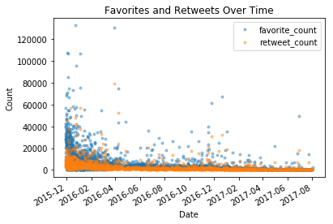

```python
# Plot frequency of both favorites and retweets over the time stamps available

df[['favorite_count', 'retweet_count']].plot(style = '.', alpha = 0.4)
plt.title('Favorites and Retweets Over Time')
plt.xlabel('Date')
plt.ylabel('Count');
```

**The above analyses and visualizations indicate that WeRateDogs was extremely popular a few years ago, as far back as the data goes, in late 2015. However, activity on the page has decreased over time.**

### Analysis 2)

**What is the most popular source of WeRateDogs' Twitter Activity for users?**

```python
# Get value counts by source
df['source'].value_counts()
```

```
Twitter for iPhone    2032
Twitter Web Client      30
TweetDeck               11
Name: source, dtype: int64
```

*The most popular way to access WeRateDogs is BY FAR the Twitter App for iPhone.*

## Analysis 3)

**What percentage of Dogs on WeRateDogs received a rating of greater than 10/10?**

```python
df['rating_numerator'].value_counts().sort_index()
```

```
3.0         1
4.0         1
5.0         2
6.0         1
7.0         1
8.0        11
9.0         7
10.0      150
11.0      579
12.0      741
13.0      496
14.0       77
15.0        2
17.0        1
27.0        1
666.0       1
1776.0      1
Name: rating_numerator, dtype: int64
```

```python
# Find total number of rating numerators that are greater than 10

ten_plus = df['rating_numerator'][df['rating_numerator'] > 10].value_counts().sum()
```

```python
# Divide the variable above by the total number of tweet_ids
ten_plus / df['tweet_id'].count()
```

```
0.9160636758321273
```

*Of the total of 2,073 total Dogs rated on the WeRateDogs Twitter Page, 1899 dogs were rated higher than 10, or approximately 91.6% of dogs!*

## Analysis 4)

*How do the individual dog stages compare in terms of favorites received?*

```
Text(0.5,1,'Favorite Counts by Dog Stage')
```

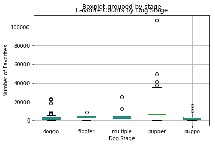

```python
# Develop box plot to explore the distribution of favorites across the various Dog Stages

ax = df.boxplot(column='favorite_count', by='stage');
ax.set_xlabel("Dog Stage")
ax.set_ylabel("Number of Favorites")
plt.title('Favorite Counts by Dog Stage')
```

*The greatest majority of favorites were not associated with any particular dog stage at all.*

```python
# Compare box plot findings with median distribution table for further insights
df.groupby('stage')['favorite_count'].describe()
```

| stage | count | mean | std | min | 25% | 50% | 75% | max |
| --- | --- | --- | --- | --- | --- | --- | --- | --- |
| doggo | 83.0 | 3354.192771 | 4312.968463 | 115.0 | 1334.00 | 2404.0 | 3477.5 | 23443.0 |
| floofer | 9.0 | 3365.333333 | 2638.906497 | 0.0 | 2467.00 | 3022.0 | 4561.0 | 8740.0 |
| multiple | 14.0 | 5143.357143 | 6447.946275 | 413.0 | 2300.25 | 3308.5 | 4094.0 | 25124.0 |
| pupper | 245.0 | 10612.195918 | 12951.117289 | 0.0 | 2818.00 | 6340.0 | 15939.0 | 107015.0 |
| puppo | 29.0 | 3062.034483 | 3324.847145 | 0.0 | 1194.00 | 2091.0 | 3831.0 | 15749.0 |

*Puppers are the clear favorite dog stage, based on number of favorites received over this time frame.*

## Analysis 5)

*What is the overall rating distribution for We Rate Dogs?*

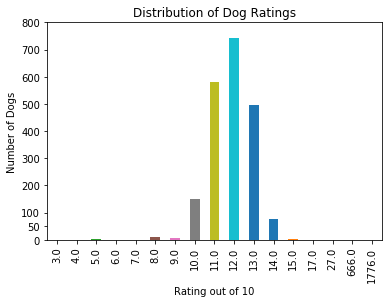

```python
# Gather dog rating distribution via bar chart
df = df.rating_numerator.value_counts().sort_index().plot('bar', title = 'Distribution of Dog Ratings')
df.set_xlabel("Rating out of 10")
df.set_ylabel("Number of Dogs")
df.set_yticks([0, 50, 100, 200, 300, 400, 500, 600, 700, 800])
plt.savefig('rating_dist')
```